# Small area estimates of vote shares: the 2022 Australian federal election

- Show All Code
- Hide All Code
- View Source

We provide estimates of vote shares at the SA1 level from the 2022 Australian federal election, making use of a mapping from polling places to SA1s provided by the Australian Electorall Commission and methods for solving inverse problems from statistics, computer science and the social sciences.

Author

Professor Simon Jackman

Published

7:17PM 11 November 2022

# Summary

- SA1 or “Statistical Area 1” is the most granular unit of geography for which the Australian Bureau of Statistics provides tabulations of demographic and social characteristics measured on the Census.
- The ABS uses 61,844 SA1s, of which 60,487 had non-zero population counts in the 2021 Census. The median population of the non-empty SA1s was 406.
- After each federal election, the AEC produces a [data file](https://www.aec.gov.au/Elections/Federal_Elections/2022/files/downloads/2022-federal-election-votes-sa1.csv) that provides voter turnout counts at each of the polling places utilised by voters residing in each SA1.
- This mapping from polling places to SA1s is a helpful tool in understanding the social and demographic correlates of the vote at a reasonably fine-grained level, exploiting the facts that the AEC supplies (1) vote tallies by party at the polling place level and (2) the Census provides social and demographic characteristics at the SA1 level.
- These data are also helpful for political parties and other groups, in that they permit us to form estimates of the political characteristics of SA1s, that in turn provide a basis for on-the-ground campaigning and mobilisation, identifying geographic targets-of-opportunity.
- A number of interesting methodological challenges arise in using data of this sort: votes by party are tabulated at the polling place level while Census characteristics are tabulated at the SA1 level. While the AEC SA1 file provides voter turnout counts by SA1 and polling place, we can not, in general, recover votes by party for SA1s exactly. This inferential problem is known as an “inverse problem” in mathematics and statistics, one in which we try to recover the unobserved *inputs* that generated observed *outputs*; in this case the inverse problem is said to be *ill-posed* in that no unique solution typically exists, with a *range* of possible inputs consistent with the observed outputs. In the social sciences this problem is called the “ecological” or “cross-level” inference problem, with a long and distinguished lineage.

# Australian electoral geography: divisions and polling places

Voter enrolment and turnout is compulsory in Australia. Electoral authorities maintain a high quality list of enrolled voters and their current addresses, often relying on information from other government agencies to keep address information current.

In 2022, Australia was partitioned into 151 electoral divisions, each one electing a single member of the House of Representatives. In 2022 an average of 102,000 voters turned out in each division. The median number of voting locations (including postal voting) was 55 per division, with 139 locations used in the large and sparsely populated division of Grey in South Australia and just 34 in Solomon centered on Darwin in the Northern Territory.

Electoral divisions sometimes span multiple local government areas and state legislative districts, but elections at these lower levels of government are not held concurrently with a Federal election.[^1] Accordingly, no great administrative complexity arises from not insisting that voters turn out at polling places close to their registered address. In short, Australian voters are not allocated to *precincts* within constituencies as is the case in the United States.

So, while many Australians opt to turn out at the polling place closest to their residence, this is far from universal. Consistent with making the legal obligation to turn out easy to fulfil, Australian voters have many options as to *where* and *how* to turn out. Consequently, the vote shares reported for a given polling place comprises a mix of voters from across the enclosing division.

# The AEC’s SA1 file

The AEC has produced a [file](https://www.aec.gov.au/Elections/Federal_Elections/2022/files/downloads/2022-federal-election-votes-sa1.csv) that provides House of Representatives voter turnout counts from the 2022 election at each of the polling places utilised by the voters residing in each SA1.

The first 25 records of this file are:

[interactive chart not shown]

## Features of the data

The AEC’s SA1 file has:

- 999,746 records with non-zero vote counts.
- 56,302 unique `ccd_id` (SA1s).[^2]
- 8,449 unique `pp_id` (polling places) with non-zero vote counts.
- 15,469,725 votes

## SA1s to polling places

For each SA1 we compute the number of polling places utilised by its voters and the share of its total votes from each of the `pp_id` used by its voters. Figure 1 shows that the modal number of polling places used per SA1 is 17, with a small cluster of SA1s whose voters make use of just 1 polling place.

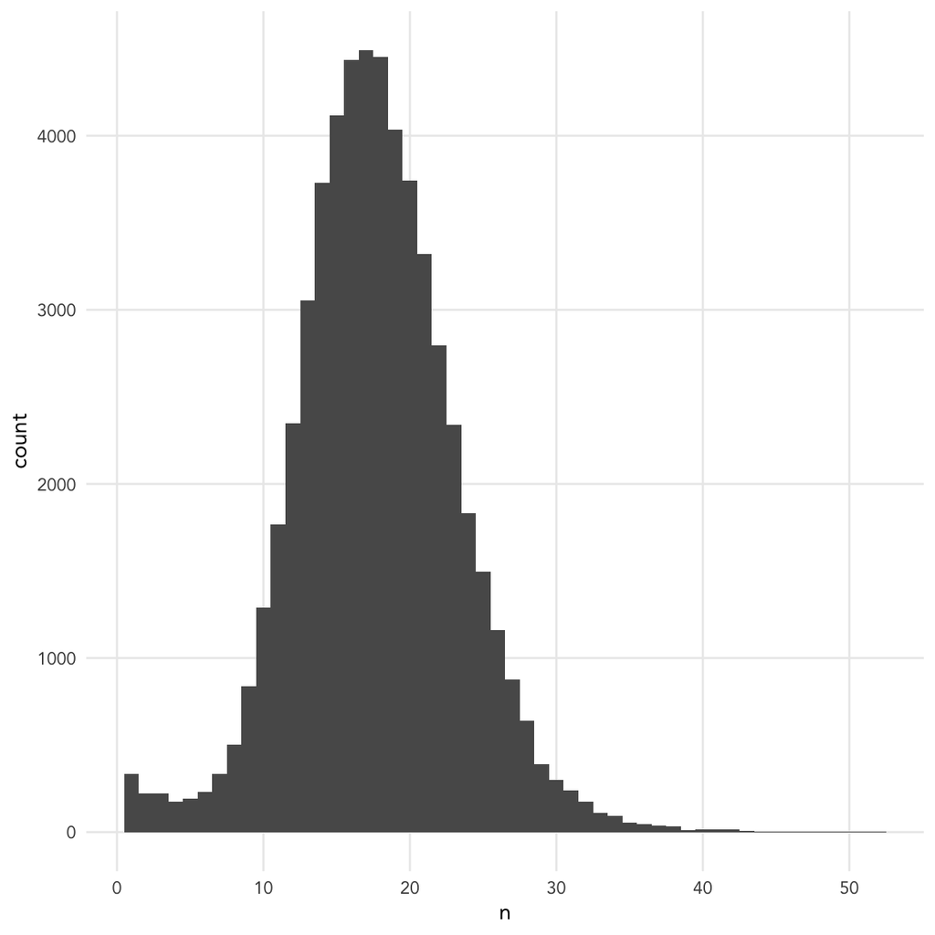

Figure 1: Histogram, number of polling places used per SA1

We also examine the concentration or diffusion of voters across polling places within each SA1. We first compute $p_{ij}$, the proportion of voters from SA1 $i$ who vote at polling place $j \in 1, \ldots, n_i$. The Gini-Simpson index
$$G_i = 1 - \sum_{j=1}^{n_i} p_{ij}^2$$
measures the *diversity* of the $p_{ij}$ within SA1 $i$ and in this case is equal to the probability that two randomly sampled voters in the $i$-th SA1 turned out at different polling places.

Figure 2 shows a series of plots of the largest value of $p_{ij}$ for each SA1plotted against the Gini-Simpson diversity index $G_i$, over a range of values for $n_i$, the number of polling places utilised by voters in a particular SA1.

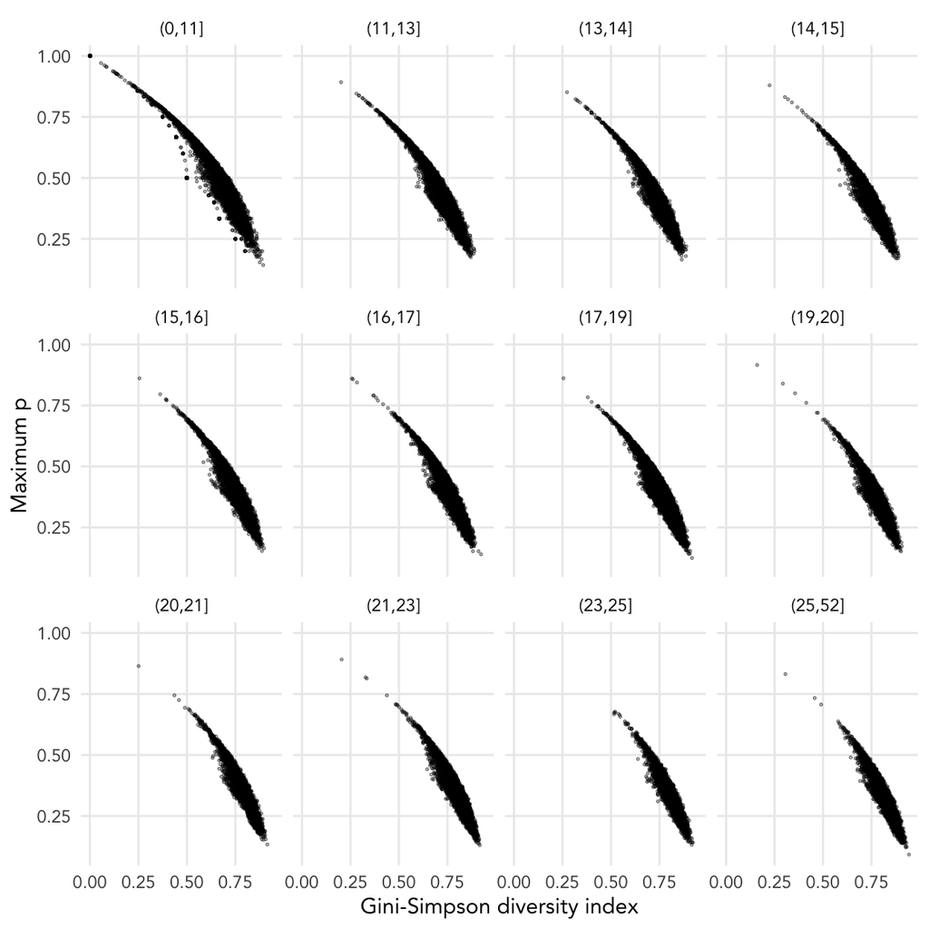

In the following table we examine the spread of SA1 votes across polling places as follows: for a given SA1 we order the contributing polling places by the number of votes from the SA1 cast at that polling place. We then compute the cumulative share of SA1 turnout as we go from the largest/most-utilised polling place to the smallest/least-utilised polling place. After a cumulative $j$ polling places, we compute the median proportion of a SA1’s turnout and the 5th and 95th percentile of the cumulative turnout across SA1s. These quantities are reported in the table below:

[interactive chart not shown]

This inspection of the data reveals

- typically, combining results from many polling places will be required to generate estimates of vote shares at the SA1 level;
- while it is sometimes the case that one or two polling places account for the bulk of votes from a given SA1, this is relatively unusual. More often than not, even **six** polling places account for less than 90% of the turnout of a SA1, and typically about **nine** polling places are required to account for 95% of turnout in any SA1.

## Matching AEC vote counts to the SA1 file

We verify that the vote tallies reported in the AEC file match vote tallies reported elsewhere in AEC election returns. We do this by comparing counts of vote cast at each `pp_id` in the SA1 level file with that in the results provided by the AEC.

There are small disparities at the divisional level, probably resulting from the ambiguities with incomplete address information, resolving those addresses to SA1s or SA1s split between CEDs. There are 15,469,725 voters in the SA1 file, while the AEC recorded 15,461,379 House of Representatives votes. Figure 3 displays the distribution of anamolies between the SA1 voter counts and the AEC results files voter counts, at the level of polling places (including division-wide tallies of absentee, postal and pre-poll declaration votes as distinct “polling places”).

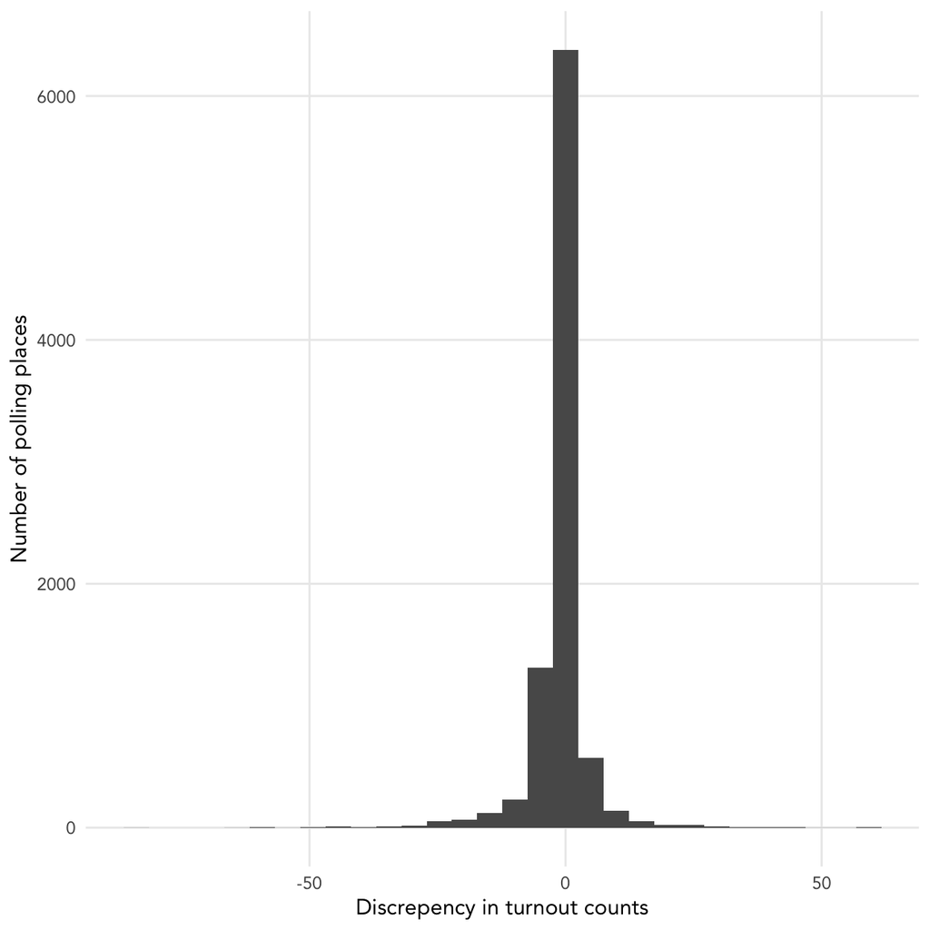

Figure 3: Histogram of differences between SA1 polling place turnout and AEC turnout

We aggregate these polling-place level disparities to the divisional level, listing the results in the following table:

[interactive chart not shown]

Divisions in suburban Sydney produces larger discrepancies in official AEC House turnout and divisional turnout in the SA1 file: Werriwa, Blaxland, Watson, Banks, Kingsford Smith, etc. Higher proportions of NESH voters is one of the distinguishing characteristics of these divisions, perhaps leading to address information being recorded on the electoral roll with errors or insufficiently complete to permit a definitive allocation of the voters to a SA-1 (and hence allocated multiple times).

## Divisions with split SA1s

Table 1: Divisions with 10 or more split SA-1s

| Division | Total SA1s | Split SA1s |
| --- | --- | --- |
| Kennedy | 475 | 15 |
| Wright | 381 | 12 |
| Bendigo | 344 | 11 |
| Hume | 395 | 11 |
| Maranoa | 445 | 11 |
| Grayndler | 345 | 10 |
| Groom | 393 | 10 |
| Mallee | 477 | 10 |